# Inspection on the Determinants of Exchange Rate(USD/TRY)

Tufan Berk Tug - IE360 - Fall 2020

# 1.Introduction

Turkey, being a country using its own currency, is seriously affected by the foreign currency exchange rates. Actually, exchange rates have an inevitable importance for every country trading with others. For those citizens that buy and use imported products a lot, increasing exchange rates are one of biggest nightmares. Due to this reason, exchange rate is one of the economic terms that even a decent person has an idea and interest in it.  
Beside the people’s individual interest, exchange rates also deeply influence one country’s general economic conditions. Turkey has high negative trade balances, namely trade deficits, recently, which implies that Turkey is a country importing more than it exports. Higher exchange rates mean less purchasing power against foreign firms and more debts. Interestingly, it is a two sided relationship: Trade balances are one of the most important factors determining exchange rates.  
After some research, it could be seen that interest rates and unemployment rates are also important determinant factors of exchange rates. For aforementioned reasons, this report inspects the relations between USD/TRY exchange rate and Turkey’s trade balance, unemployment rate and weighted interest rate applied to commercial loans. Data is pulled from an excel file that can be accessed from Electronic Data Delivery System [“EVDS”](https://evds2.tcmb.gov.tr/index.php?/evds/serieMarket). Date range used for this study is from August 2012 to August 2020 in monthly manner due to data accessibility reasons.

# 2.Analysis

## a.Data Manipulation

To start with, data must be imported from the excel file with read_excel function and brought to an understandable and more useful shape with some manipulations. First entries with column names can be seen after manipulation as an example:

```r
EVDS <- read_excel("EVDS.xlsx",
    range = "A1:E98", col_types = c("text", "numeric", "numeric", "numeric", "numeric"))
names(EVDS) <- c("Date", "TrBal", "ExcRate", "IntRate", "UnempRate")
EVDS$Date <- as.yearmon(EVDS$Date)
EVDS <- cbind(EVDS,format(EVDS$Date, "%Y"),format(EVDS$Date, "%m"))
names(EVDS)[6:7] <- c("Year","Month")
head(EVDS)
```

```
##       Date TrBal  ExcRate IntRate UnempRate Year Month
## 1 Aug 2012 -1272 1.785840 10.8960       8.0 2012    08
## 2 Sep 2012 -2600 1.795630 11.0600       8.3 2012    09
## 3 Oct 2012 -1133 1.794140  9.6800       8.3 2012    10
## 4 Nov 2012 -4035 1.785450  9.3660       8.6 2012    11
## 5 Dec 2012 -4810 1.779090  8.7975       9.3 2012    12
## 6 Jan 2013 -5449 1.763859  8.7475       9.7 2013    01
```

## b.Data Visualisation and Comparative Analysis

### Exchange Rates

Firstly, it would be a good idea to analyze our main data, exchange rate levels, by visualizing in a yearly barplot to see its pattern:

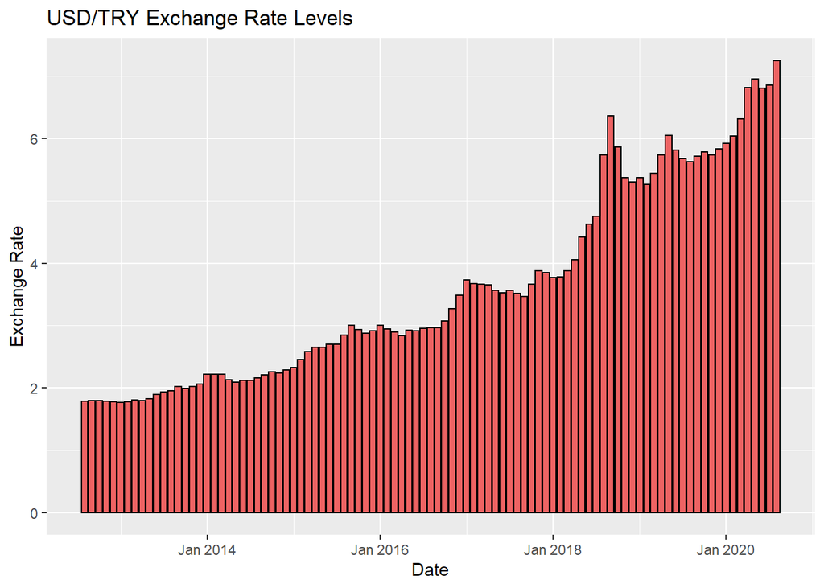

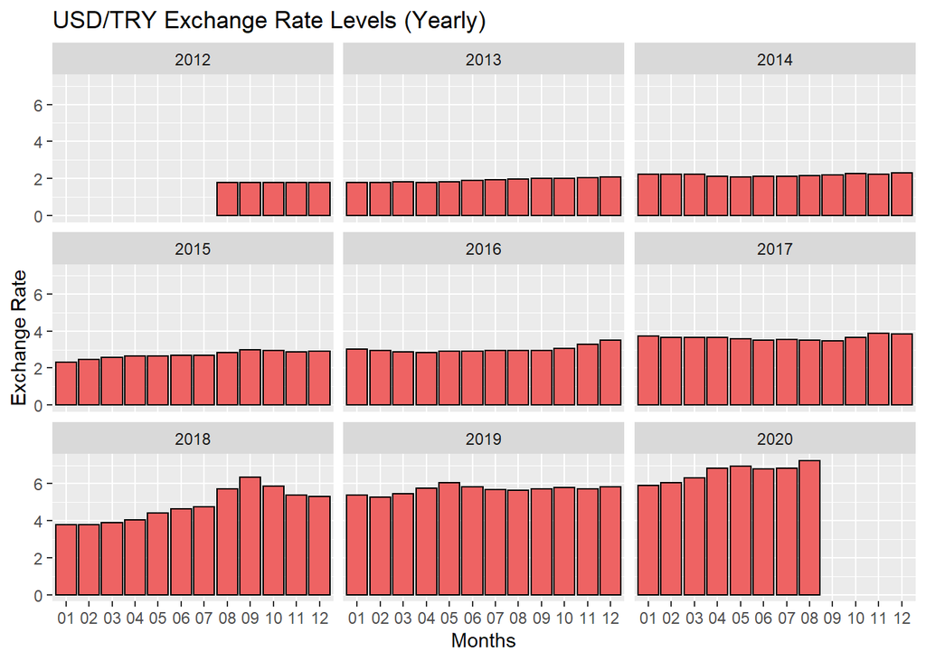

As seen in yearly graphs, there is no periodic pattern in yearly basis, but there is an overall increase over years. To explain this overall increase, we will now analyze 3 other time series data and compare them to exchange rate levels. Since exchange rates does not have any periodicity over years, there is no need for examining potential determinants in a yearly basis.

### Trade Balance Levels

Let’s start with visualizing trade balance levels and checking the correlation between exchange rate and trade balance levels to see if there is a relation or not:

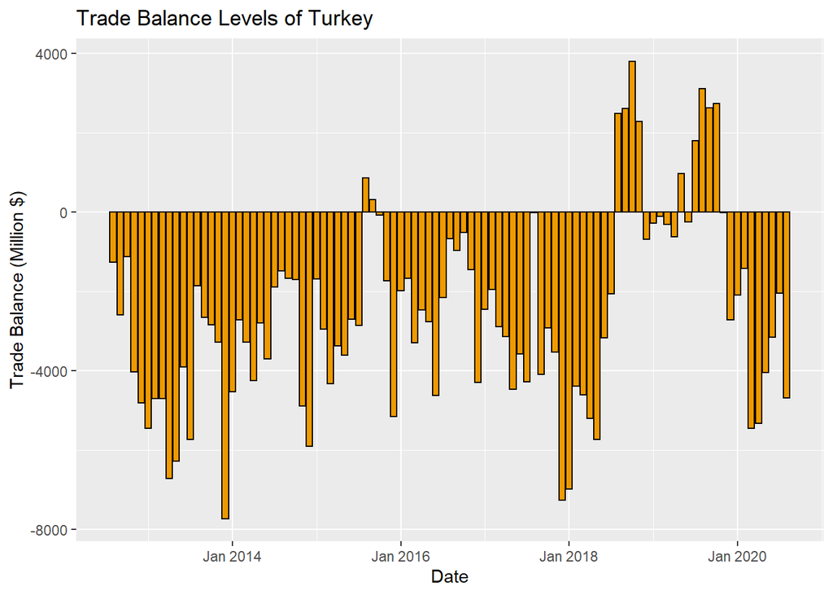

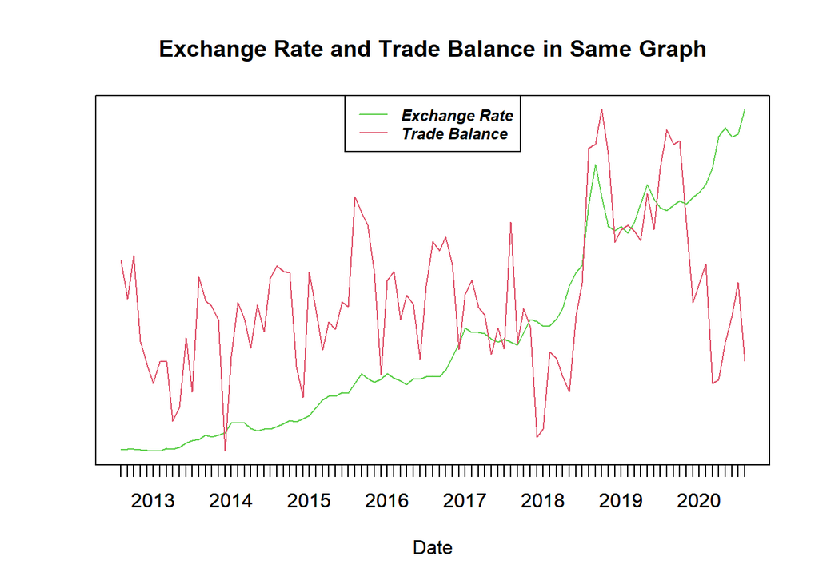

```
## [1] "Correlation value between Trade Balance and Exchange Rate: 0.4015"
```

There is no obvious relation between two variables, but it can be seen that there are many corresponding tops and bottoms. Correlation value also indicates a relation although it is not so powerful.

### Interest Rates

Now, we will check commercial loan interest rates to see if we will be able to see a stronger relation:

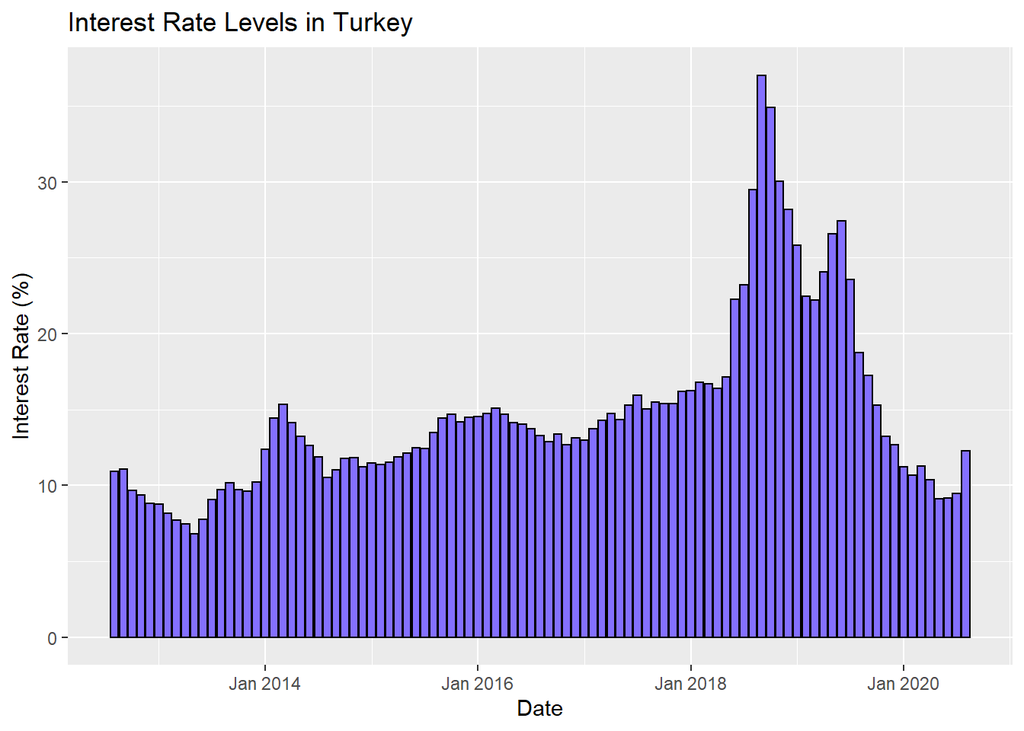

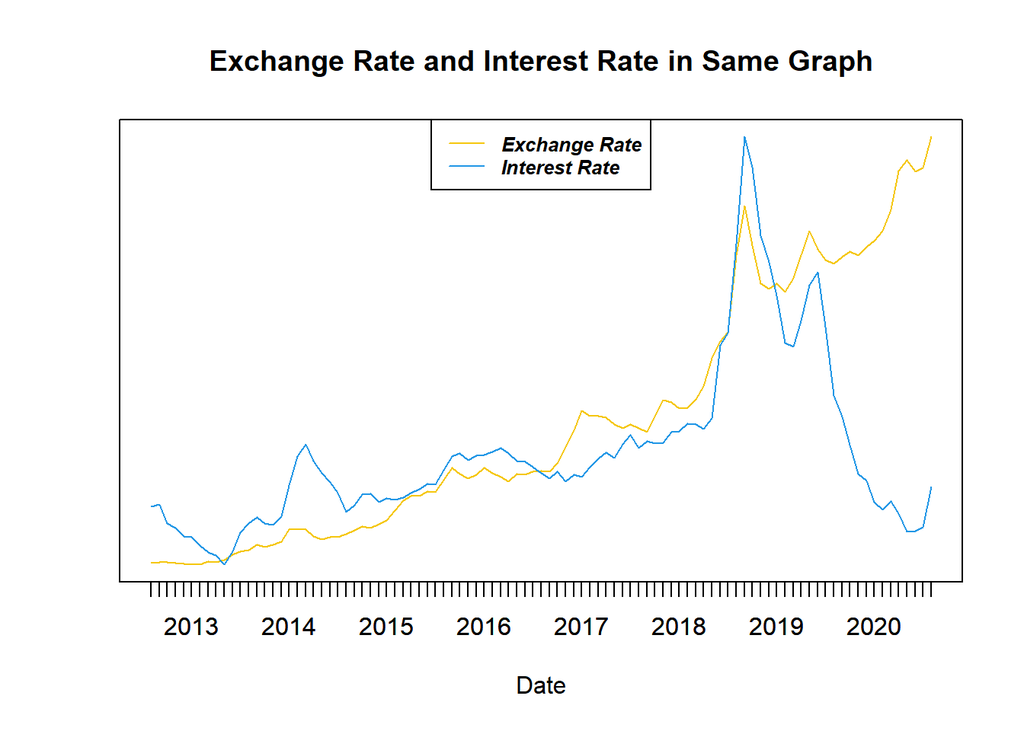

```
## [1] "Correlation value between Interest Rate and Exchange Rate: 0.5419"
```

There is a more obvious relation between interest rate and exchange rate as proposed by comparative graph and correlation value. However, there is an inconsistency between two variables after mid-2019 compared to more consistent earlier data, which may stem from government intervention to interest rates.

### Unemployment Rates

Lastly, here is the visualization and analysis of unemployment rate and its relation with exchange rate:

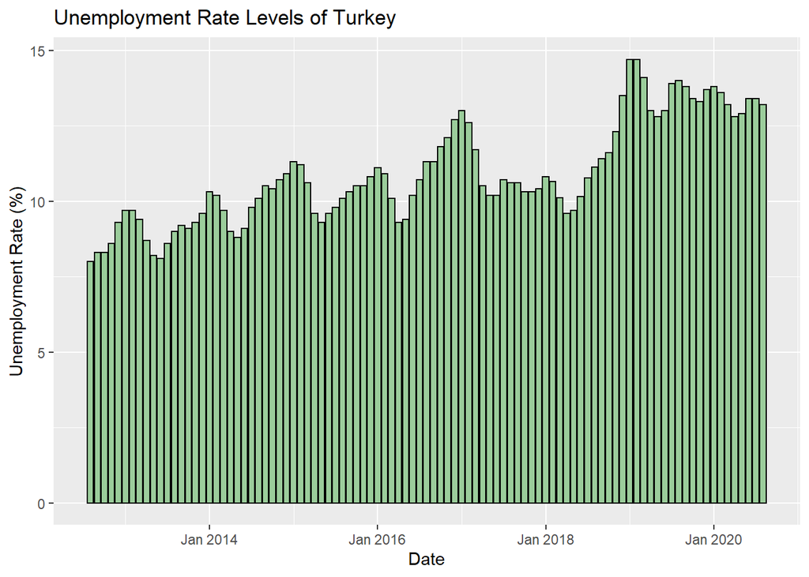

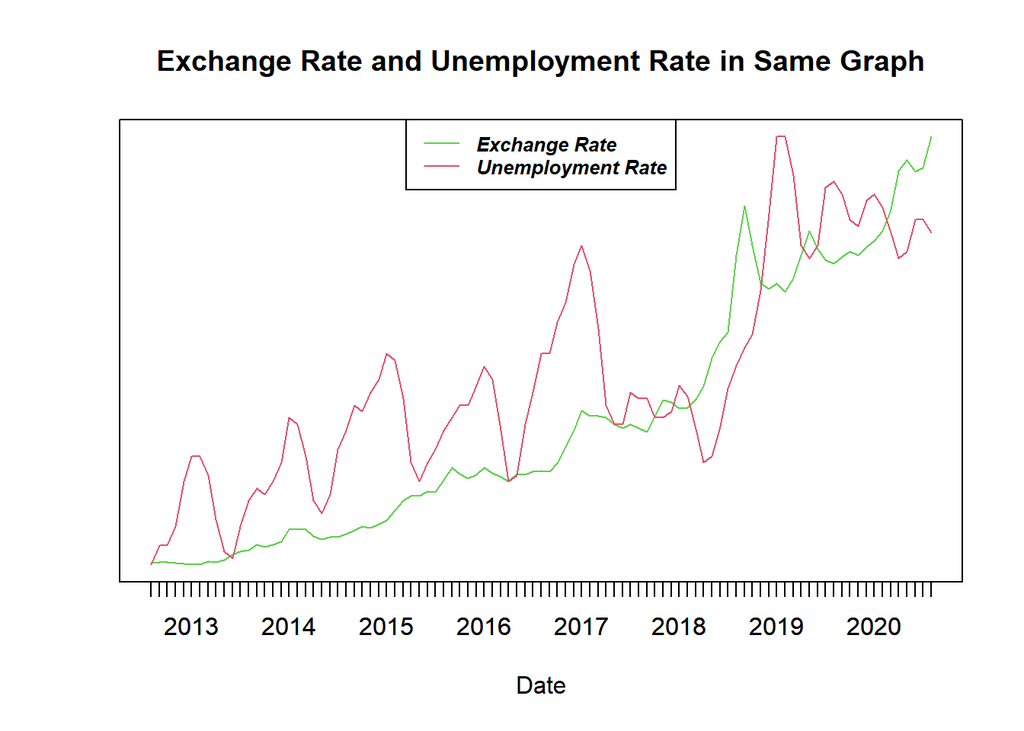

```
## [1] "Correlation value between Unemployment Rate and Exchange Rate: 0.8309"
```

Relation between exchange rate and unemployment rate is even more obvious than interest rates. However, unemployment rate has a seasonal pattern which weakens the correlation. Seasonally adjusted version that is provided by [TÜİK](https://data.tuik.gov.tr/Bulten/Index?p=Isgucu-Istatistikleri-Agustos-2020-33792) would be more preferred:

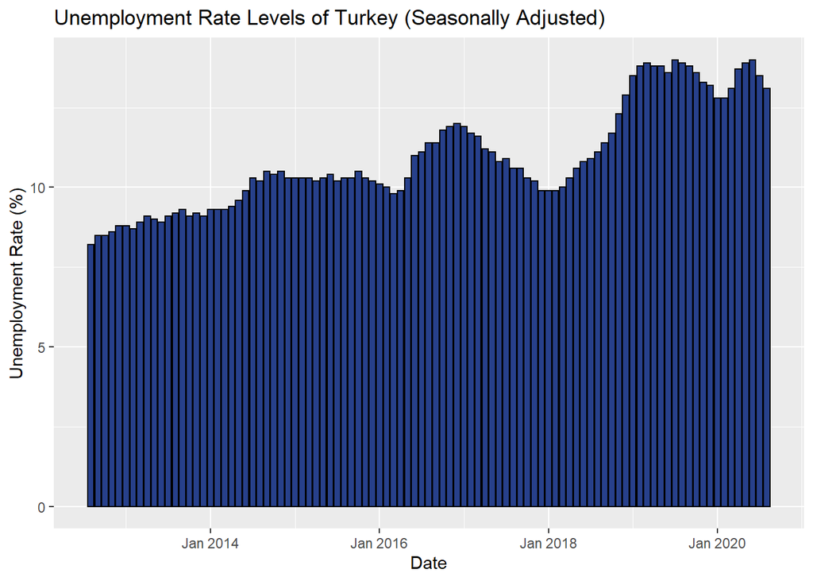

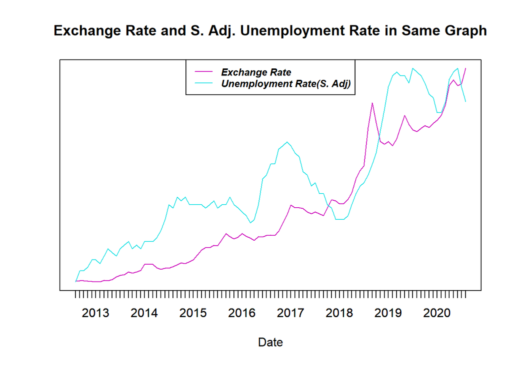

```
## [1] "Correlation value between Seasonally Adjusted Unemployment Rate and Exchange Rate: 0.891"
```

As we suggested, seasonally adjusted version of data yields us a stronger relationship and so higher correlation.

# 3.Conclusion

After conducting these mathematical and visual analyses, we see that the chosen three variables are good candidates for explaining the movement of exchange rate. As we did for unemployment rate, there could be need for more adjustments also for interest rate and trade deficits so that we have better correlations. As a final analysis, checking the adjusted R-squared value of linear regression model using these three variables might be insightful:

```r
summary(lm(ExcRate~IntRate+TrBal+UnempRate2, data = EVDS))
```

```
##
## Call:
## lm(formula = ExcRate ~ IntRate + TrBal + UnempRate2, data = EVDS)
##
## Residuals:
##      Min       1Q   Median       3Q      Max
## -1.09598 -0.45137 -0.07298  0.45108  1.77016
##
## Coefficients:
##               Estimate Std. Error t value Pr(>|t|)
## (Intercept) -6.778e+00  5.707e-01 -11.876  < 2e-16 ***
## IntRate      7.112e-02  1.447e-02   4.916 3.79e-06 ***
## TrBal       -1.056e-04  3.566e-05  -2.960   0.0039 **
## UnempRate2   8.313e-01  4.764e-02  17.449  < 2e-16 ***
## ---
## Signif. codes:  0 '***' 0.001 '**' 0.01 '*' 0.05 '.' 0.1 ' ' 1
##
## Residual standard error: 0.6522 on 93 degrees of freedom
## Multiple R-squared:  0.837,  Adjusted R-squared:  0.8317
## F-statistic: 159.2 on 3 and 93 DF,  p-value: < 2.2e-16
```

With an adjusted R-squared value of 0.8317 and high significance levels for each determinant, created linear regression model shows us that potential determinants do a decent work on explaining the behavior of exchange rate.